Data from IBM , to nalysize consumer behaviour during marketing campagin.

```python
#Import required libraries
import pandas as pd
import numpy as np
import matplotlib.pyplot as plt
import seaborn as sns
```

```python
#import data in pd df
df = pd.read_csv('WA_Fn-UseC_-Marketing-Customer-Value-Analysis.csv')
```

# Exploratory Data Analysis

```python
# Check the first 5 rows
df.head()
```

|  | Customer | State | Customer Lifetime Value | Response | Coverage | Education | Effective To Date | EmploymentStatus | Gender | Income | ... | Months Since Policy Inception | Number of Open Complaints | Number of Policies | Policy Type | Policy | Renew Offer Type | Sales Channel | Total Claim Amount | Vehicle Class | Vehicle Size |
| --- | --- | --- | --- | --- | --- | --- | --- | --- | --- | --- | --- | --- | --- | --- | --- | --- | --- | --- | --- | --- | --- |
| 0 | BU79786 | Washington | 2763.519279 | No | Basic | Bachelor | 2/24/11 | Employed | F | 56274 | ... | 5 | 0 | 1 | Corporate Auto | Corporate L3 | Offer1 | Agent | 384.811147 | Two-Door Car | Medsize |
| 1 | QZ44356 | Arizona | 6979.535903 | No | Extended | Bachelor | 1/31/11 | Unemployed | F | 0 | ... | 42 | 0 | 8 | Personal Auto | Personal L3 | Offer3 | Agent | 1131.464935 | Four-Door Car | Medsize |
| 2 | AI49188 | Nevada | 12887.431650 | No | Premium | Bachelor | 2/19/11 | Employed | F | 48767 | ... | 38 | 0 | 2 | Personal Auto | Personal L3 | Offer1 | Agent | 566.472247 | Two-Door Car | Medsize |
| 3 | WW63253 | California | 7645.861827 | No | Basic | Bachelor | 1/20/11 | Unemployed | M | 0 | ... | 65 | 0 | 7 | Corporate Auto | Corporate L2 | Offer1 | Call Center | 529.881344 | SUV | Medsize |
| 4 | HB64268 | Washington | 2813.692575 | No | Basic | Bachelor | 2/3/11 | Employed | M | 43836 | ... | 44 | 0 | 1 | Personal Auto | Personal L1 | Offer1 | Agent | 138.130879 | Four-Door Car | Medsize |

5 rows × 24 columns

```python
# Check dimensions of df
df.shape
```

```
(9134, 24)
```

```python
#Check names of the columns
df.columns
```

```
Index(['Customer', 'State', 'Customer Lifetime Value', 'Response', 'Coverage',
       'Education', 'Effective To Date', 'EmploymentStatus', 'Gender',
       'Income', 'Location Code', 'Marital Status', 'Monthly Premium Auto',
       'Months Since Last Claim', 'Months Since Policy Inception',
       'Number of Open Complaints', 'Number of Policies', 'Policy Type',
       'Policy', 'Renew Offer Type', 'Sales Channel', 'Total Claim Amount',
       'Vehicle Class', 'Vehicle Size'],
      dtype='object')
```

```python
#Check null values
df.isnull().sum()
```

```
Customer                         0
State                            0
Customer Lifetime Value          0
Response                         0
Coverage                         0
Education                        0
Effective To Date                0
EmploymentStatus                 0
Gender                           0
Income                           0
Location Code                    0
Marital Status                   0
Monthly Premium Auto             0
Months Since Last Claim          0
Months Since Policy Inception    0
Number of Open Complaints        0
Number of Policies               0
Policy Type                      0
Policy                           0
Renew Offer Type                 0
Sales Channel                    0
Total Claim Amount               0
Vehicle Class                    0
Vehicle Size                     0
dtype: int64
```

We notice that the data does not contains null values.

```python
#Check the statiscs of income
df.describe()['Income']
```

```
count     9134.000000
mean     37657.380009
std      30379.904734
min          0.000000
25%          0.000000
50%      33889.500000
75%      62320.000000
max      99981.000000
Name: Income, dtype: float64
```

```python
#Check for unique values
df.nunique()
```

```
Customer                         9134
State                               5
Customer Lifetime Value          8041
Response                            2
Coverage                            3
Education                           5
Effective To Date                  59
EmploymentStatus                    5
Gender                              2
Income                           5694
Location Code                       3
Marital Status                      3
Monthly Premium Auto              202
Months Since Last Claim            36
Months Since Policy Inception     100
Number of Open Complaints           6
Number of Policies                  9
Policy Type                         3
Policy                              9
Renew Offer Type                    4
Sales Channel                       4
Total Claim Amount               5106
Vehicle Class                       6
Vehicle Size                        3
dtype: int64
```

#### We notice that the distripution is in 5 states , also we have 4 sales channels and other insights we can get from it

```python
#Check the 5 states names
df['State'].unique()
```

```
array(['Washington', 'Arizona', 'Nevada', 'California', 'Oregon'],
      dtype=object)
```

```python
#Check the 4 Sales Channels
df['Sales Channel'].unique()
```

```
array(['Agent', 'Call Center', 'Web', 'Branch'], dtype=object)
```

```python
#Check for null values
df.isnull().sum()
```

```
Customer                         0
State                            0
Customer Lifetime Value          0
Response                         0
Coverage                         0
Education                        0
Effective To Date                0
EmploymentStatus                 0
Gender                           0
Income                           0
Location Code                    0
Marital Status                   0
Monthly Premium Auto             0
Months Since Last Claim          0
Months Since Policy Inception    0
Number of Open Complaints        0
Number of Policies               0
Policy Type                      0
Policy                           0
Renew Offer Type                 0
Sales Channel                    0
Total Claim Amount               0
Vehicle Class                    0
Vehicle Size                     0
dtype: int64
```

```python
# WE do not need the coulm of Number of Policies so we will drop it
df2 = df.drop(['Number of Policies'],axis=1)
```

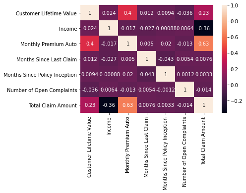

```python
#Relationship analysis, with correlation matrix
correlation = df2.corr()
sns.heatmap(correlation,xticklabels=correlation.columns,yticklabels=correlation.columns,annot=True)
```

# Asking Questions

# Data analysis and Recommendations

## Overall Engagment to the marketing campagin

- What is the overall engagment to the marketing Campagin?

```python
#in the colum response , it indicates does the customer have a response toward the marketing campagin or not, we can calculate it by
df.groupby('Response').count()['Customer']
```

```
Response
No     7826
Yes    1308
Name: Customer, dtype: int64
```

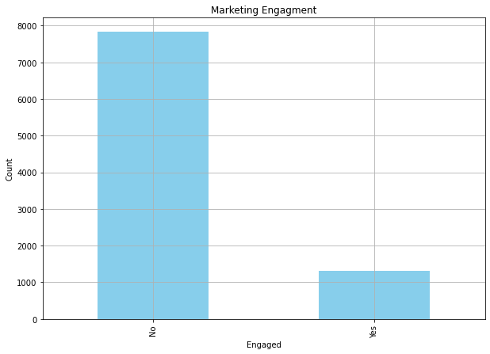

```python
#Visualization of customer respone
ax = df.groupby('Response').count()['Customer'].plot(kind='bar',color='skyblue',grid=True,figsize=(10,7),title='Marketing Engagment')
ax.set_xlabel('Engaged')
ax.set_ylabel('Count')
plt.show()
```

```python
#Check the persentage of each response
Percentage_per_response = df.groupby('Response').count()['Customer']/df.shape[0]*100
Percentage_per_response
```

```
Response
No     85.679877
Yes    14.320123
Name: Customer, dtype: float64
```

we can see that the majority of customers 85% , did not respond to the campagin

## Engagement rates by offer type

- Different types of offers will work differently for the customers So we want to answer the question, what types of offers woked best for the engaged customers?
- What is the best offer that get highest rate of engagement and what is the lowest one?

```python
eng_by_offer_type = df.loc[df['Response']=='Yes'].groupby(['Renew Offer Type']).count()['Customer']/df.groupby('Renew Offer Type').count()['Customer']
eng_by_offer_type
```

```
Renew Offer Type
Offer1    0.158316
Offer2    0.233766
Offer3    0.020950
Offer4         NaN
Name: Customer, dtype: float64
```

```python
#df.loc[df['Response']=='Yes'].groupby(['Renew Offer Type']).count()['Customer']/df.shape[0]
```

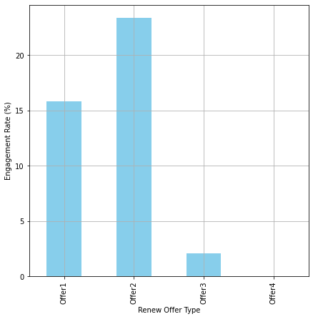

```python
#Visualize the prvious data
ax  = (Eng_rate_by_offer_type*100).plot(kind='bar', figsize=(7, 7), color='skyblue',grid=True)
ax.set_ylabel('Engagement Rate (%)')
plt.show()
```

Offer2 has the highset engagement rate than others while offer 4 has no engagement rate. We can seach more in the geographic location ant its relationship between people who accept the offers.

```python
# Number of customer that renew per offer
df.loc[df['Response']=='Yes'].groupby(['Renew Offer Type']).count()['Customer']
```

```
Renew Offer Type
Offer1    594
Offer2    684
Offer3     30
Name: Customer, dtype: int64
```

### what is the relationship between the engagement rate of vehicle class?

```python
# Engagment rates by offer type and vehicle class
Eng_by_offer_type_vechile_class = df.loc[df['Response']=='Yes'].groupby(['Renew Offer Type', 'Vehicle Class']).count()['Customer']/df.groupby('Renew Offer Type').count()['Customer']
Eng_by_offer_type_vechile_class
```

```
Renew Offer Type  Vehicle Class
Offer1            Four-Door Car    0.070362
                  Luxury Car       0.001599
                  Luxury SUV       0.004797
                  SUV              0.044776
                  Sports Car       0.011194
                  Two-Door Car     0.025586
Offer2            Four-Door Car    0.114833
                  Luxury Car       0.002051
                  Luxury SUV       0.004101
                  SUV              0.041012
                  Sports Car       0.016405
                  Two-Door Car     0.055366
Offer3            Four-Door Car    0.016760
                  Two-Door Car     0.004190
Name: Customer, dtype: float64
```

```python
Eng_by_offer_type_vechile_class.unstack().fillna(0)
```

| Vehicle Class Renew Offer Type | Four-Door Car | Luxury Car | Luxury SUV | SUV | Sports Car | Two-Door Car |
| --- | --- | --- | --- | --- | --- | --- |
| Offer1 | 0.070362 | 0.001599 | 0.004797 | 0.044776 | 0.011194 | 0.025586 |
| Offer2 | 0.114833 | 0.002051 | 0.004101 | 0.041012 | 0.016405 | 0.055366 |
| Offer3 | 0.016760 | 0.000000 | 0.000000 | 0.000000 | 0.000000 | 0.004190 |

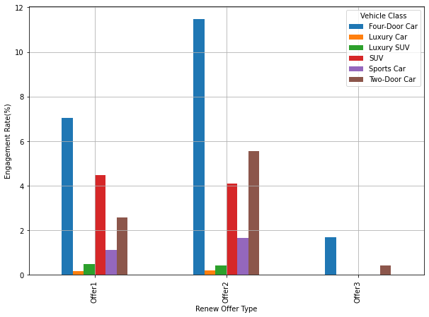

```python
ax = (Eng_by_offer_type_vechile_class.unstack().fillna(0)*100).plot(kind='bar',figsize=(10,7),grid=True)
ax.set_ylabel('Engagement Rate(%)')
plt.show()
```

So we can notice that vehicle class " Four-Dooe car" have highest engagment rate in all offers, so marketers should focus on them in the next marketing campagin

### Does location have effect of engagment rate and which offers matchs with locations?

```python
#Eng by location code
Eng_by_offer_type_vechile_Area = df.loc[df['Response']=='Yes'].groupby(['Renew Offer Type','Location Code']).count()['Customer']/df.groupby('Renew Offer Type').count()['Customer']
Eng_by_offer_type_vechile_Area
```

```
Renew Offer Type  Location Code
Offer1            Rural            0.011194
                  Suburban         0.137527
                  Urban            0.009595
Offer2            Rural            0.038961
                  Suburban         0.161996
                  Urban            0.032809
Offer3            Rural            0.004190
                  Suburban         0.012570
                  Urban            0.004190
Name: Customer, dtype: float64
```

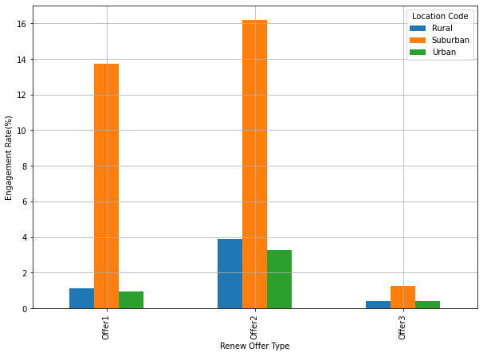

```python
ax = (Eng_by_offer_type_vechile_Area.unstack().fillna(0)*100).plot(kind='bar',figsize=(10,7),grid=True)
ax.set_ylabel('Engagement Rate(%)')
plt.show()
```

We can notice that suburan area are the highest in all offers types, where markters should focus more in their next campagin

```python
Eng_vechile_class_Location_Code = df.loc[df['Response']=='Yes'].groupby(['Vehicle Class','Location Code']).count()['Customer']/df.groupby('Location Code').count()['Customer']
Eng_vechile_class_Location_Code
```

```
Vehicle Class  Location Code
Four-Door Car  Rural            0.050761
               Suburban         0.079945
               Urban            0.045512
Luxury Car     Suburban         0.002076
Luxury SUV     Suburban         0.005191
SUV            Rural            0.010152
               Suburban         0.040491
               Urban            0.022756
Sports Car     Rural            0.010152
               Suburban         0.011421
               Urban            0.003793
Two-Door Car   Rural            0.020305
               Suburban         0.035300
               Urban            0.015171
Name: Customer, dtype: float64
```

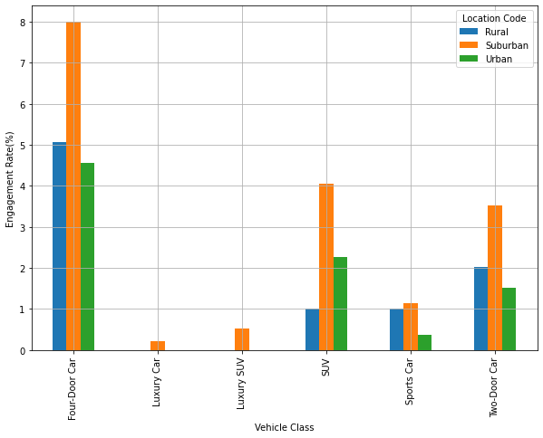

```python
ax = (Eng_vechile_class_Location_Code.unstack().fillna(0)*100).plot(kind='bar',figsize=(10,7),grid=True)
ax.set_ylabel('Engagement Rate(%)')
plt.show()
```

## Engagement rate by sales channel

What is the best sales channel?

```python
#Engagement rate by sales channel
Eng_by_Sales_Channels = df.loc[df['Response']=='Yes'].groupby(['Sales Channel']).count()['Customer']/df.groupby('Sales Channel').count()['Customer']
Eng_by_Sales_Channels
```

```
Sales Channel
Agent          0.191544
Branch         0.114531
Call Center    0.108782
Web            0.117736
Name: Customer, dtype: float64
```

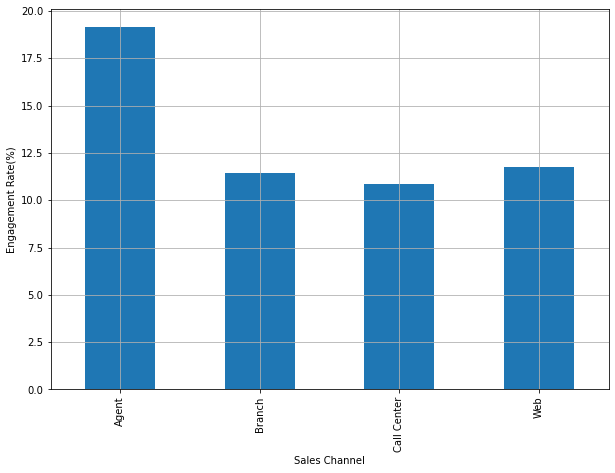

```python
#Vizualize
ax = (Eng_by_Sales_Channels.fillna(0)*100).plot(kind='bar',figsize=(10,7),grid=True)
ax.set_ylabel('Engagement Rate(%)')
plt.show()
```

We Notice that agent sales channel is the best channel among other , so we should impower it in the next campagin

```python
df.groupby('Sales Channel').count()['Customer']
```

```
Sales Channel
Agent          3477
Branch         2567
Call Center    1765
Web            1325
Name: Customer, dtype: int64
```

# Engagement rate by sales channel and vehicle size

```python
Eng_rate_by_sales_channel_vehicle_size = df.loc[df['Response']=='Yes'].groupby(['Sales Channel','Vehicle Size']).count()['Customer']/df.groupby('Sales Channel').count()['Customer']
Eng_rate_by_sales_channel_vehicle_size
```

```
Sales Channel  Vehicle Size
Agent          Large           0.020708
               Medsize         0.144953
               Small           0.025884
Branch         Large           0.021036
               Medsize         0.074795
               Small           0.018699
Call Center    Large           0.013598
               Medsize         0.067989
               Small           0.027195
Web            Large           0.013585
               Medsize         0.095094
               Small           0.009057
Name: Customer, dtype: float64
```

```python
#Eng_rate_by_sales_channel_vehicle_size = Eng_rate_by_sales_channel_vehicle_size.unstack().fillna(0)
```

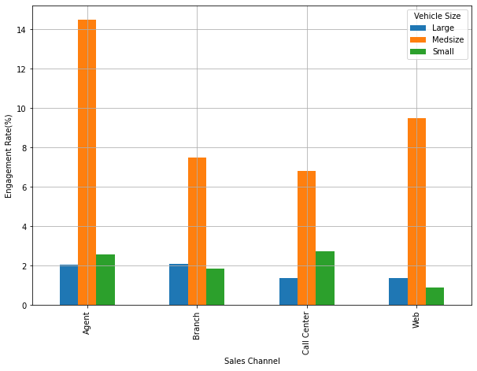

```python
ax = (Eng_rate_by_sales_channel_vehicle_size.unstack().fillna(0)*100).plot(kind='bar',figsize=(10,7),grid=True)
ax.set_ylabel('Engagement Rate(%)')
plt.show()
```